# Regression and Volleyball

Jessi Kehe

This R Markdown document was adapted from documents created by Professor Bret Larget.

### Setup details

# Lecture: Regression Overview

### Background

- Many problems in Statistics and Data Science involve examining the relationship between variables.
- A common setting is when:
  - a single quantitative variable is deemed a *response variable*
  - one or more other variables are treated as *explanatory variables* or *predictors*.
- Such models are referred to as *linear models*
  - In a standard linear model, the response variable is assumed to have a normal distribution given the predictors.

#### Special cases

- Linear models can be categorized based on the number and types of the predictors.
  - *simple linear regression*: a single quantitative predictor
  - *multiple regression*: multiple quantitative predictors
  - *one-way analysis of variance*: a single categorical predictor
  - *analysis of variance*: multiple categorical predictors

#### Generalizations

- When the distribution of the response variable is not modeled with a normal distribution, such as when it is a count or a single 0/1 response, it is often preferable to use a *generalized linear model*.
  - *logistic regression*: for 0/1 response variables;
  - *Poisson regression*: for non-negative count data.
- At other times, it is preferable to model a categorical predictor as having a distribution itself. Some of these models are called *mixed effects models*.

## Example

- International Arrival airport wait time data from Chicago in 2018.

```r
chicago <- read_csv2("../../data/chicago-2018.csv")
chicago
```

```
## # A tibble: 7,008 x 21
##    airport terminal date  hour  us_avg_wait us_max_wait non_us_avg_wait
##    <chr>   <chr>    <chr> <chr>       <dbl>       <dbl>           <dbl>
##  1 ORD     Termina… 1/1/… 0000…           4          14               7
##  2 ORD     Termina… 1/1/… 0500…           9          21              13
##  3 ORD     Termina… 1/1/… 0600…           9          30              16
##  4 ORD     Termina… 1/1/… 0700…           6          23              12
##  5 ORD     Termina… 1/1/… 0800…           5          20              13
##  6 ORD     Termina… 1/1/… 0900…          18          34              16
##  7 ORD     Termina… 1/1/… 1000…          11          25               9
##  8 ORD     Termina… 1/1/… 1100…           6          31              27
##  9 ORD     Termina… 1/1/… 1200…          16          52              25
## 10 ORD     Termina… 1/1/… 1300…          23          46              25
## # … with 6,998 more rows, and 14 more variables: non_us_max_wait <dbl>,
## #   all_avg_wait <dbl>, all_max_wait <dbl>, all_n_0..15 <dbl>,
## #   all_n_16..30 <dbl>, all_n_31..45 <dbl>, all_n_46..60 <dbl>,
## #   all_n_61..90 <dbl>, all_n_91..120 <dbl>, all_n_120.. <dbl>,
## #   all_excluded <dbl>, all_total <dbl>, all_flights <dbl>, all_booths <dbl>
```

- Model the number of booths as a function of the total number of passengers.
  - How did the airport plan on staffing?

```r
chicago_1 <- chicago %>%
  select(all_total,all_booths) %>%
  drop_na()

chicago_1 %>%
  summarize_all(list(
    min = min,
    mean = mean,
    median = median,
    max = max)) %>%
  pivot_longer(cols = everything(), names_to="stat",values_to = "value")
```

```
## # A tibble: 8 x 2
##   stat               value
##   <chr>              <dbl>
## 1 all_total_min        6
## 2 all_booths_min       0
## 3 all_total_mean     799.
## 4 all_booths_mean     15.1
## 5 all_total_median   542.
## 6 all_booths_median   14
## 7 all_total_max     3401
## 8 all_booths_max      38
```

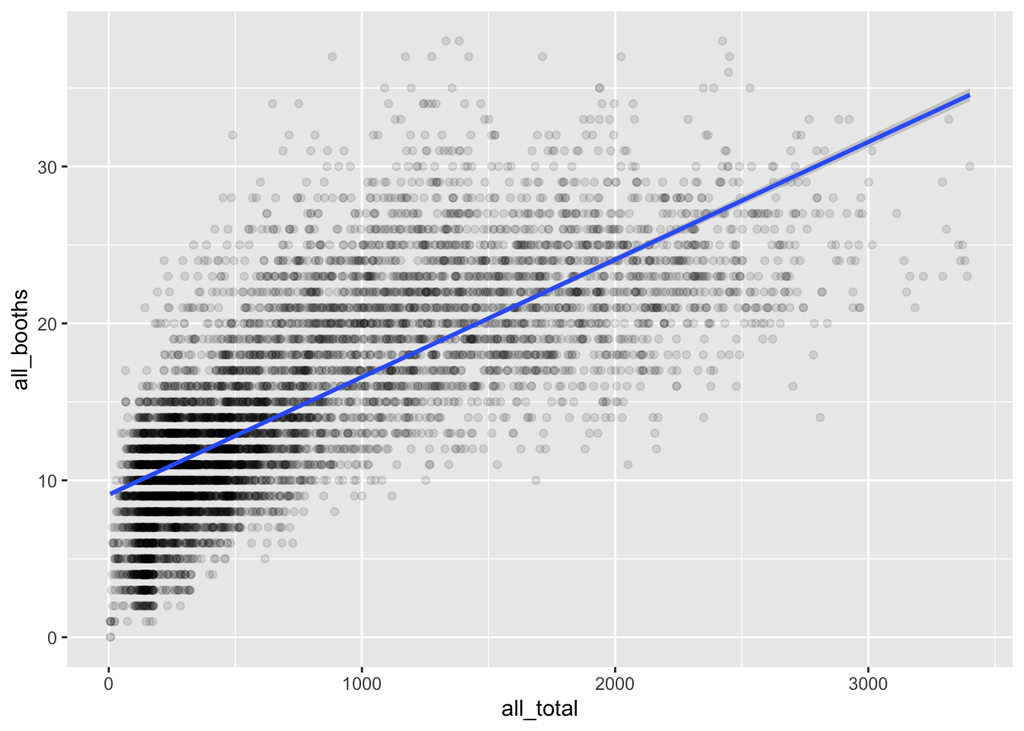

```r
ggplot(chicago_1, aes(x=all_total,y=all_booths)) +
  geom_point(alpha=0.1) +
  geom_smooth(method = "lm")
```

```r
fit_1 <- lm(all_booths ~ all_total, data=chicago_1)

summary(fit_1)
```

```
##
## Call:
## lm(formula = all_booths ~ all_total, data = chicago_1)
##
## Residuals:
##      Min       1Q   Median       3Q      Max
## -16.1382  -2.9110  -0.3907   2.4243  21.2991
##
## Coefficients:
##              Estimate Std. Error t value Pr(>|t|)
## (Intercept) 9.085e+00  8.182e-02  111.03   <2e-16 ***
## all_total   7.492e-03  7.826e-05   95.73   <2e-16 ***
## ---
## Signif. codes:  0 '***' 0.001 '**' 0.01 '*' 0.05 '.' 0.1 ' ' 1
##
## Residual standard error: 4.415 on 7006 degrees of freedom
## Multiple R-squared:  0.5668, Adjusted R-squared:  0.5667
## F-statistic:  9165 on 1 and 7006 DF,  p-value: < 2.2e-16
```

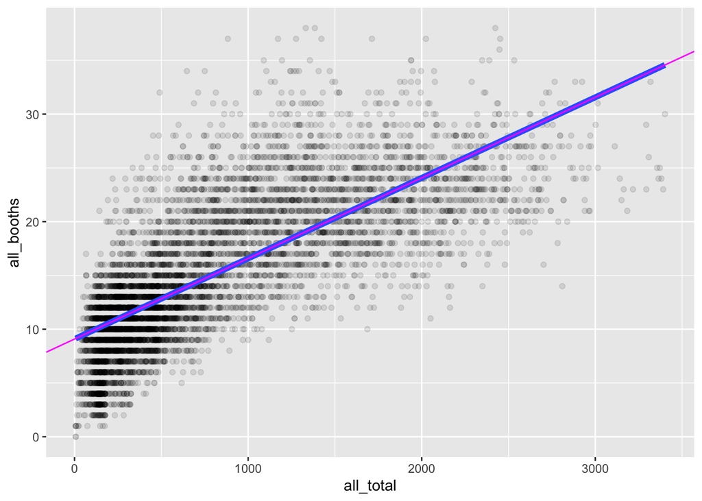

```r
ggplot(chicago_1, aes(x=all_total,y=all_booths)) +
  geom_point(alpha=0.1) +
  geom_smooth(method = "lm", se=FALSE, size = 2) +
  geom_abline(slope = coef(fit_1)[[2]], intercept = coef(fit_1)[[1]], color="magenta")
```

# Lecture: Introduction to Correlation

## Correlation coefficient, $r$

The correlation coefficient, $r$, is a summary statistic describing a particular relationship between two quantitative variables.

The correlation coefficient…

- Measures the strength and direction of a linear relationship
- Is used for quantitative variables
- Does not distinguish the two variables
- Has no units of measurement
- $-1 \leq r \leq 1$

$$r = \frac{\sum_{i=1}^n \left(\frac{x_i - \bar{x}}{s_x}\right)
\left(\frac{y_i - \bar{y}}{s_y}\right)}{n-1}$$

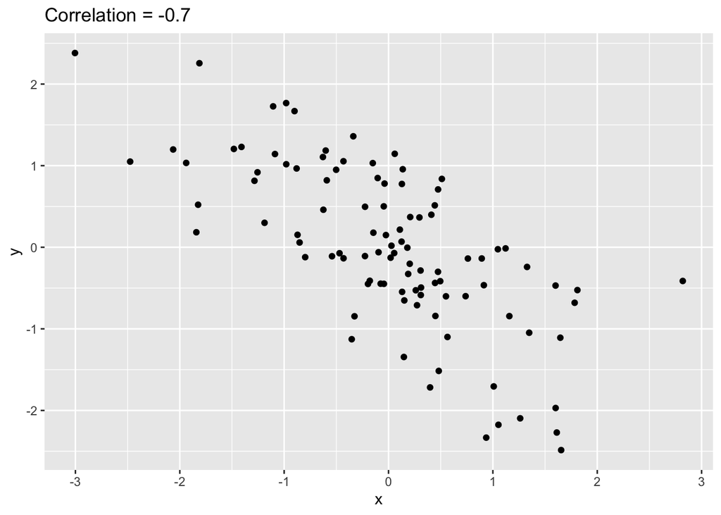

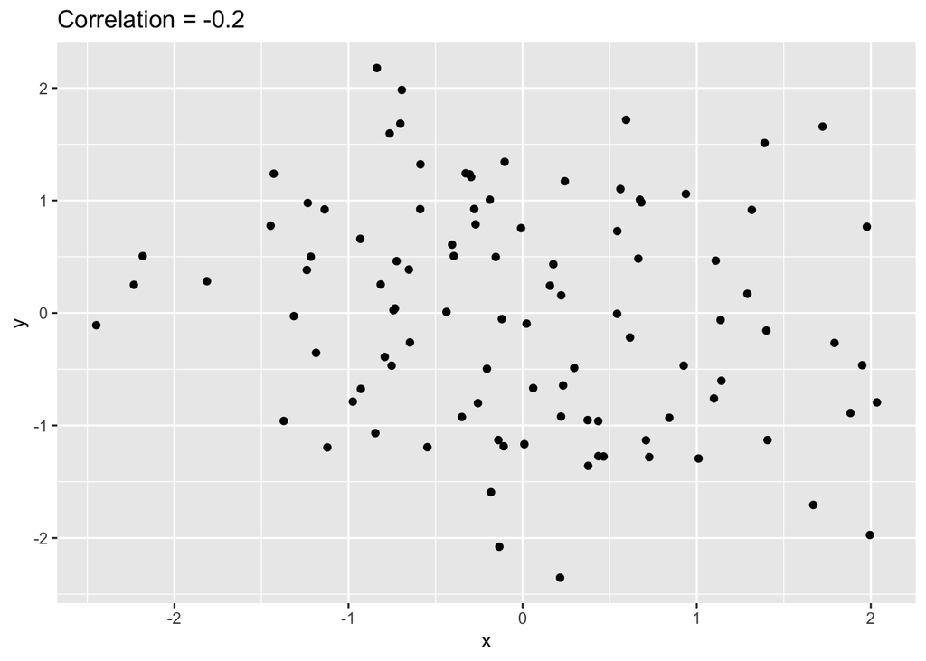

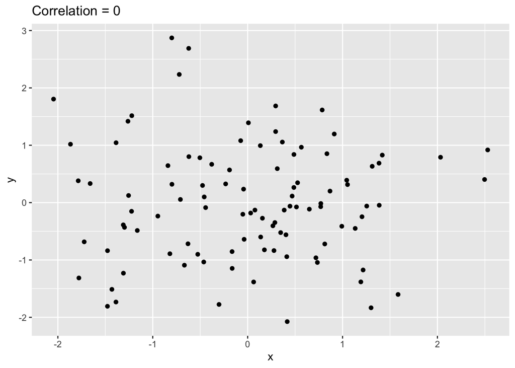

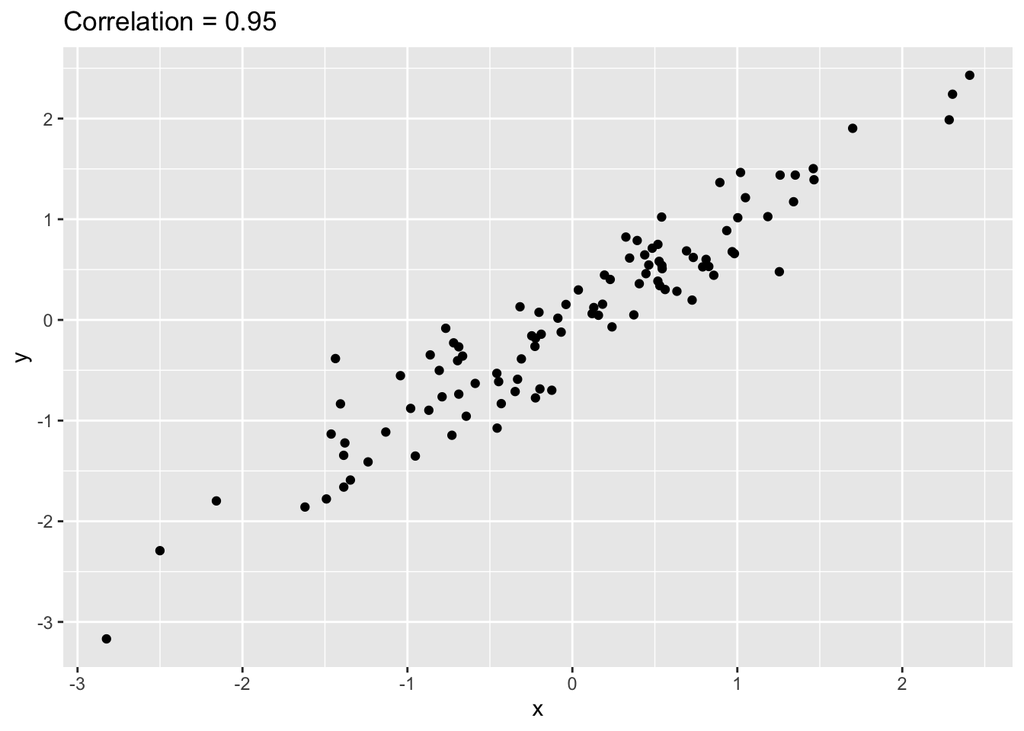

### Thought Quiz

1. Why is there no distinction between the explanatory and response variables in correlation?
2. Why do both variables have to be quantitative?
3. How does changing the units of measurement change correlation?
4. Why doesn’t a tight fit to a horizontal line imply strong correlation?

# Lecture: Introduction to Regression

Correlation tells us about the strength and direction of a line.  
- What if we want a description of how the variables vary together?

The regression line…  
- A regression line is a straight line that describes how a response variable y changes as an explanatory variable x changes  
- We can use a regression line to predict the value of y for a given value of x  
- The distinction between explanatory and response variables is important  
- The Least-squares regression line is the unique line such that the sum of the squared vertical (y) distances between the data points and the line is as small as possible.

#### Regression formulas

The simple linear model has the form

$$y = a_0 + a_1 x + \varepsilon$$
where $y$ is the response variable, $x$ is the explantory variable, $a_0$ is the y-intercept, $a_1$ is the slope, and $\varepsilon$ is the error.

Using observations $(x_1,y_1), \ldots, (x_n,y_n)$, we can estimate $a_0$ and $a_1$ to get our Least-squares regression line as

$$\hat{y}_i = \hat{a}_0 + \hat{a}_1 x_i,$$
where $\hat{y}_i$ is the predicted response corresponding to $x_i$, and $\hat{a}_0$ and $\hat{a}_1$ are the estimated intercept and slope, respectively.

Least-squares Estimation: minimize the squared errors with respect to the unknown parameters.
- This is accomplished by minimizing the following with respect to the unknown parameters:
$$\sum_{i=1}^n(y_i - \hat{y}_i)^2 = \sum_{i=1}^n(y_i - (\hat{a}_0 + \hat{a}_1 x_i))^2$$
- This results in the following estimators:

Slope:
$$\hat{a}_1 = r \frac{s_y}{s_x}$$
where $r$ is the correlation coefficient, $s_y$ is the sample standard deviation for $y$, and $s_x$ is the sample standard deviation for $x$.

Intercept:
$$\hat{a}_0 = \bar{y} - \hat{a}_1 \bar{x}$$
where $\bar{y}$ and $\bar{x}$ are the sample means of the $y$ and $x$ variables, respectively.

# Lecture: Regression Example

We are going to generate a fake data set to use for our example. By using fake data, we can also check how close our regression estimates match the true values we used to simulate our data.

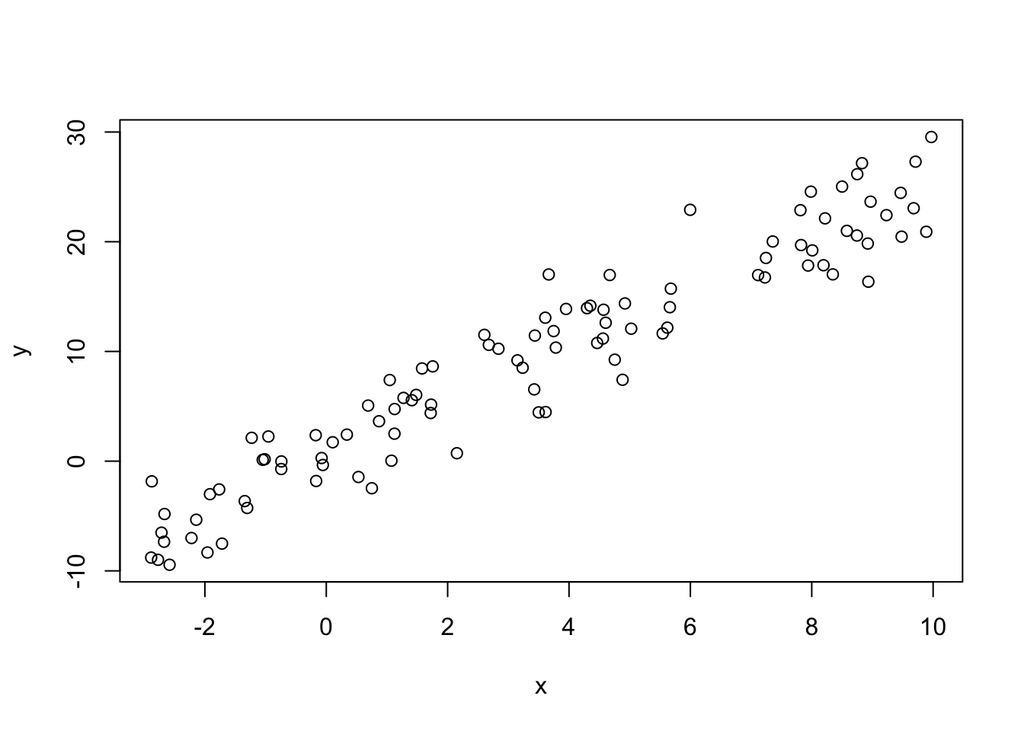

```r
## Generate our fake dataset
set.seed(246810)
n <- 100 ## sample size
a0 <- 1  ## intercept
a1 <- 2.5  ## slope
x <- runif(n, -3, 10)  ## explantory variable
y <- rnorm(n,a0+a1*x,3)  ## response variable

plot(x,y)
```

```r
## Estimate our slope and intercept
mx <- mean(x)
my <- mean(y)
sx <- sd(x)
sy <- sd(y)

r <- cor(x,y)
r
```

```
## [1] 0.9567482
```

```r
a1_hat <- r *sy/sx
a1_hat
```

```
## [1] 2.462811
```

```r
a0_hat <- my - a1_hat*mx
a0_hat
```

```
## [1] 0.8643708
```

We also can use `lm()` to estimate the slope and intercept:

```r
df0 <- tibble(x=x, y=y)
lm0 <- lm(y~x, df0)
summary(lm0)
```

```
##
## Call:
## lm(formula = y ~ x, data = df0)
##
## Residuals:
##     Min      1Q  Median      3Q     Max
## -6.5064 -2.0083  0.2062  1.9766  7.2757
##
## Coefficients:
##             Estimate Std. Error t value Pr(>|t|)
## (Intercept)  0.86437    0.39085   2.211   0.0293 *
## x            2.46281    0.07565  32.557   <2e-16 ***
## ---
## Signif. codes:  0 '***' 0.001 '**' 0.01 '*' 0.05 '.' 0.1 ' ' 1
##
## Residual standard error: 2.951 on 98 degrees of freedom
## Multiple R-squared:  0.9154, Adjusted R-squared:  0.9145
## F-statistic:  1060 on 1 and 98 DF,  p-value: < 2.2e-16
```

```r
cf <- coef(lm0)
cf
```

```
## (Intercept)           x
##   0.8643708   2.4628111
```

### Residual plots

One approach for checking if our linear assumption holds is to create a residual plot. Recall that residual corresponding to the $i$th observation is $r_i = y_i - \hat{y}_i$.

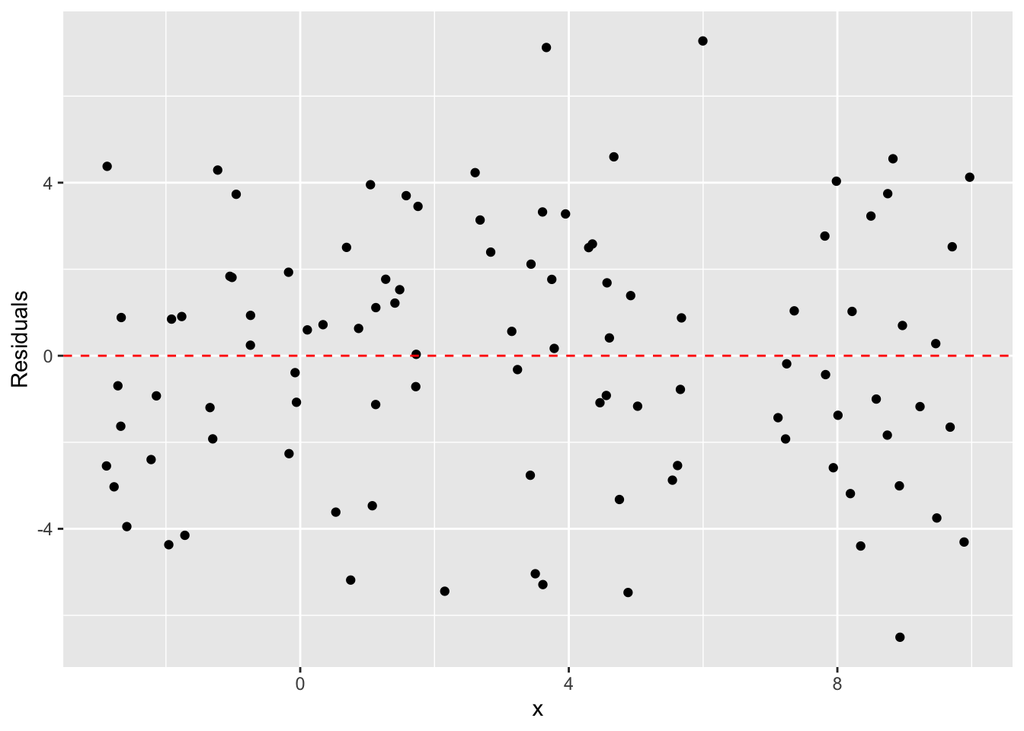

```r
library(modelr)
df0 <- df0 %>%
  add_residuals(lm0) %>%
  add_predictions(lm0)

ggplot(df0, aes(x=x, y =resid)) +
  geom_point() +
  xlab("x") +
  ylab("Residuals") +
  geom_hline(aes(yintercept=0), color="red", linetype = "dashed")
```

As a comparison, below is a residual plot for a different simulated data set.

Do you see any pattern in this residual plot?

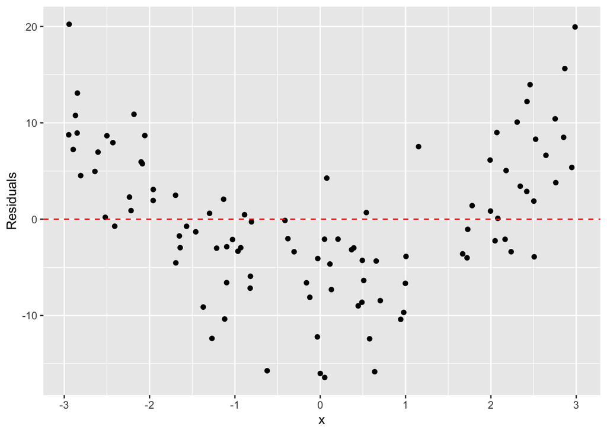

There is a clear pattern. The residuals near the boundaries are positive and the residuals near the middle of the x range are negative.

This suggests that the relationship between y and x is not linear and appears to be quadratic.

# Lecture: Volleyball and Correlation

### Background

- The UW Volleyball team won the 2019 Big 10 volleyball championship.
- As we examine regression and correlation, we will use season-long team statistics from all 332 Division I women’s volleyball teams.

### Data

- The source of the data is https://stats.ncaa.org/.
- Professor Larget had clicked to navigate to pages with summaries for multiple statistics, downloaded the data in Excel spread sheets, and saved the data into .CSV format.
- The following block of code combines these different data sets.
  - There is a single variable for the team and conference, which was split into two using `stringr` commands and regular expressions.
- Finally, the manipulated data set was saved into a .CSV file for further use.

```r
aces <- read_csv("../../data/aces.csv")
assists <- read_csv("../../data/assists.csv")
blocks <- read_csv("../../data/blocks.csv")
digs <- read_csv("../../data/digs.csv")
hitting <- read_csv("../../data/hitting.csv")
kills <- read_csv("../../data/kills.csv")
opponents <- read_csv("../../data/opponent-hitting.csv")
wl <- read_csv("../../data/win-loss.csv")

## Remove redundant columns
remove_redundant <- function(x){
  x <- x %>%
    select(-Rank,-`W-L`,-`Per Set`) %>%
    arrange(Team)
  return ( x )
}

aces <- remove_redundant(aces)
assists <- remove_redundant(assists)
blocks <- remove_redundant(blocks)
digs <- remove_redundant(digs)

## Hit Pct. is (Kills - Errors) / Attacks
hitting <- hitting %>%
  select(-Rank,-S,-`W-L`,-`Pct.`) %>%
  mutate(Hit_pct = (Kills - Errors)/`Total Attacks`) %>%
  arrange(Team)
kills <- remove_redundant(kills)
opponents <- opponents %>%
  select(-Rank,-S,-`Opp Pct`) %>%
  mutate(Opp_pct = (`Opp Kills` - `Opp Errors`)/`Opp Attacks`) %>%
  arrange(Team)
wl <- wl %>%
  select(-Rank,-`Pct.`) %>%
  mutate(Win_pct = W/(W+L)) %>%
  arrange(Team)

## join the data
vb <- wl %>%
  left_join(aces) %>%
  left_join(assists) %>%
  left_join(blocks) %>%
  left_join(digs) %>%
  left_join(hitting) %>%
##  left_join(kills) %>% ## kills are also in hitting
  left_join(opponents) %>%
  rename(Sets = S)

## separate team from conference
## Tricky because conference follows team name in parentheses
##   but some team names include location in parentheses
## Catch the last set of () in each string
##   with spaces, dashes, letters, and numbers between
conference_pattern <- "\\([- a-zA-Z0-9]+\\)$"
#str_extract(vb$Team,conference_pattern)

vb <- vb %>%
  mutate(Conference =
           str_sub(str_extract(Team,conference_pattern),2,-2)) %>%
  mutate(Team =
           str_remove(Team,conference_pattern)) %>%
  select(Team,Conference,everything())

rm(conference_pattern)

write_csv(vb,"../../data/volleyball-team-2019.csv")
```

### Big 10 and Regression

- Our volleyball data set has season statistics from 332 teams.
- We will examine only the Big 10 teams (14 of them) to explore a regression relationship to predict win percentage with the number of kills per set.
- We will then examine relationships between summary statistics with estimated regression coefficients.

#### Big 10 Data and Variables

##### Get the Big Ten data

```r
big10 <- vb %>%
  filter(Conference == "Big Ten")
```

##### Graphical Exploration

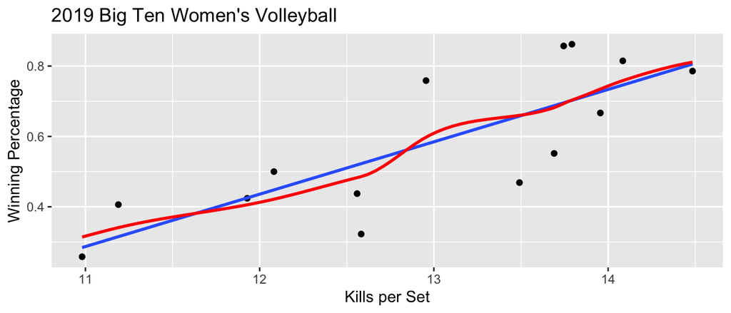

```r
ggplot(big10, aes(x=Kills/Sets,y=Win_pct)) +
  geom_point() +
  geom_smooth(method="lm", se=FALSE) +
  geom_smooth(se=FALSE,color="red") +
  xlab("Kills per Set") +
  ylab("Winning Percentage") +
  ggtitle("2019 Big Ten Women's Volleyball")
```

##### Summary Statistics

```r
x <- big10$Kills/big10$Sets
y <- big10$Win_pct
mx <- mean(x)
my <- mean(y)
sx <- sd(x)
sy <- sd(y)
r <- cor(x,y)
slope <- r *sy/sx
intercept <- my - slope*mx
slope
```

```
## [1] 0.1488341
```

```r
intercept
```

```
## [1] -1.350161
```

```r
fit <- lm(y ~ x)
coef(fit)
```

```
## (Intercept)           x
##  -1.3501612   0.1488341
```

# Lecture: Within Conference Relationships

### Data

- Use the data file created previously

```r
vb <- read_csv("../../data/volleyball-team-2019.csv")
```

### Explore Relationships Between Variables with Win Percentage within Conferences

```r
vb %>%
  select(Team, Conference, W, L, Win_pct) %>%
  mutate(w2 = W/(W+L))
```

```
## # A tibble: 332 x 6
##    Team               Conference        W     L Win_pct    w2
##    <chr>              <chr>         <dbl> <dbl>   <dbl> <dbl>
##  1 A&M-Corpus Christi Southland        19    12   0.613 0.613
##  2 Abilene Christian  Southland         7    19   0.269 0.269
##  3 Air Force          Mountain West     8    22   0.267 0.267
##  4 Akron              MAC              16    12   0.571 0.571
##  5 Alabama            SEC              12    17   0.414 0.414
##  6 Alabama A&M        SWAC             18    14   0.562 0.562
##  7 Alabama St.        SWAC             17    21   0.447 0.447
##  8 Albany (NY)        America East     16    10   0.615 0.615
##  9 Alcorn             SWAC              7    23   0.233 0.233
## 10 American           Patriot          24     7   0.774 0.774
## # … with 322 more rows
```

```r
vb %>%
  group_by(Conference) %>%
  summarize(n=n(),
            mean_win_pct = mean(Win_pct),
            mean_win_pct_2 = sum(W)/(sum(W)+sum(L))) %>%
  arrange(desc(mean_win_pct)) %>%
  print(n=50)
```

```
## # A tibble: 32 x 4
##    Conference        n mean_win_pct mean_win_pct_2
##    <chr>         <int>        <dbl>          <dbl>
##  1 Pac-12           12        0.584          0.582
##  2 Big Ten          14        0.580          0.570
##  3 SEC              13        0.576          0.574
##  4 Big 12            9        0.571          0.566
##  5 Horizon           9        0.548          0.554
##  6 AAC              12        0.547          0.551
##  7 C-USA            13        0.544          0.548
##  8 ACC              15        0.542          0.543
##  9 Ivy League        8        0.538          0.538
## 10 WCC              10        0.529          0.529
## 11 Patriot           9        0.528          0.527
## 12 Big West          9        0.522          0.52
```

[output cut: 20 more lines]

##### Plot Win Percentage versus Kills per Set for all Conferences

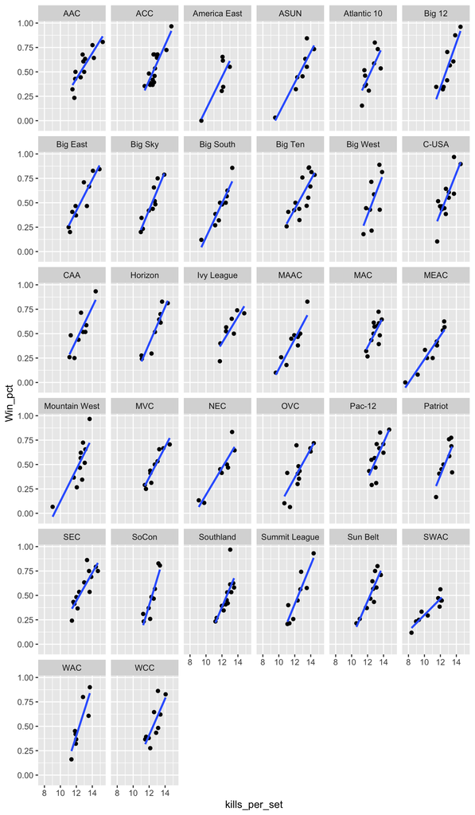

```r
vb <- vb %>%
  mutate(kills_per_set = Kills/Sets)

ggplot(vb, aes(x=kills_per_set,y=Win_pct)) +
  geom_point() +
  geom_smooth(se=FALSE,method="lm") +
  facet_wrap(~Conference)
```

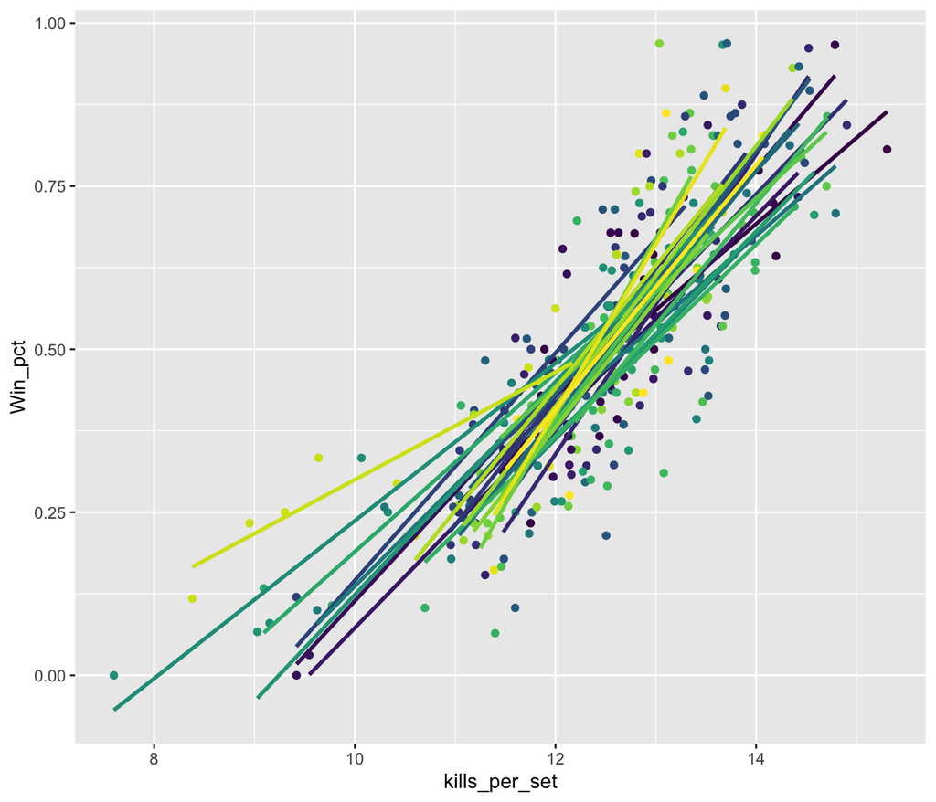

```r
ggplot(vb, aes(x=kills_per_set,y=Win_pct,color=Conference)) +
##  geom_point() +
##  geom_smooth(se=FALSE,method="lm")
  geom_point(show.legend=FALSE) +
  geom_smooth(se=FALSE,method="lm",show.legend=FALSE)
```

1. Calculate the correlation coefficients and slopes for each conference

```r
get_slope <- function(x,y)
{
  fit <- lm(y ~ x)
  return ( coef(fit)[2] )
}

kills_summary <- vb %>%
  group_by(Conference) %>%
  summarize(r = cor(kills_per_set,Win_pct),
            b = get_slope(kills_per_set,Win_pct))
kills_summary
```

```
## # A tibble: 32 x 3
##    Conference       r     b
##    <chr>        <dbl> <dbl>
##  1 AAC          0.862 0.132
##  2 ACC          0.845 0.182
##  3 America East 0.821 0.167
##  4 ASUN         0.917 0.158
##  5 Atlantic 10  0.726 0.175
##  6 Big 12       0.882 0.230
##  7 Big East     0.920 0.160
##  8 Big Sky      0.929 0.197
##  9 Big South    0.927 0.174
## 10 Big Ten      0.795 0.149
## # … with 22 more rows
```

2. Examine these summaries

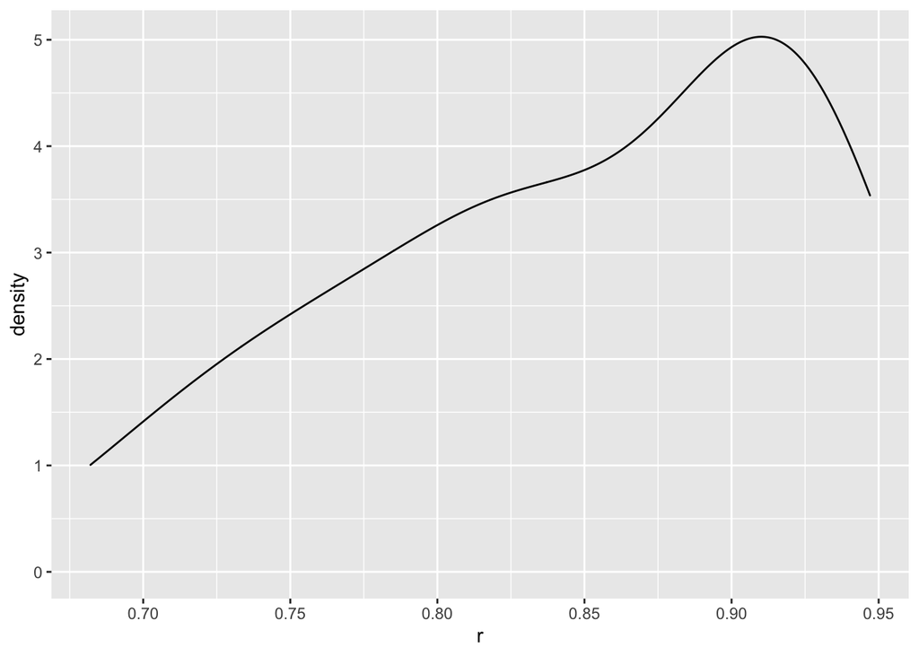

```r
ggplot(kills_summary, aes(x=r)) +
  geom_density()
```

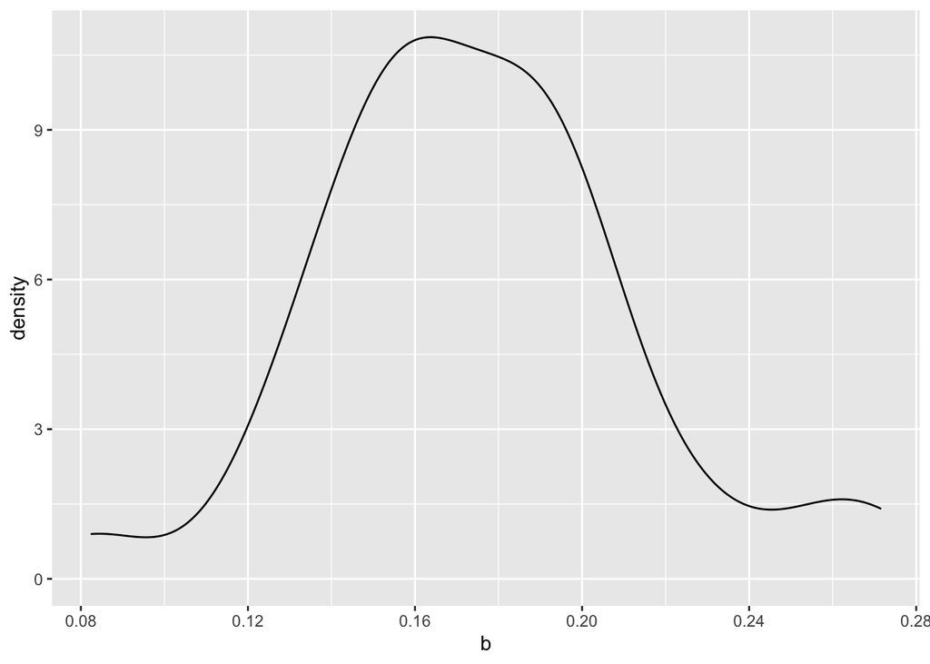

```r
ggplot(kills_summary, aes(x=b)) +
  geom_density()
```

3. Write a function to examine for other variables

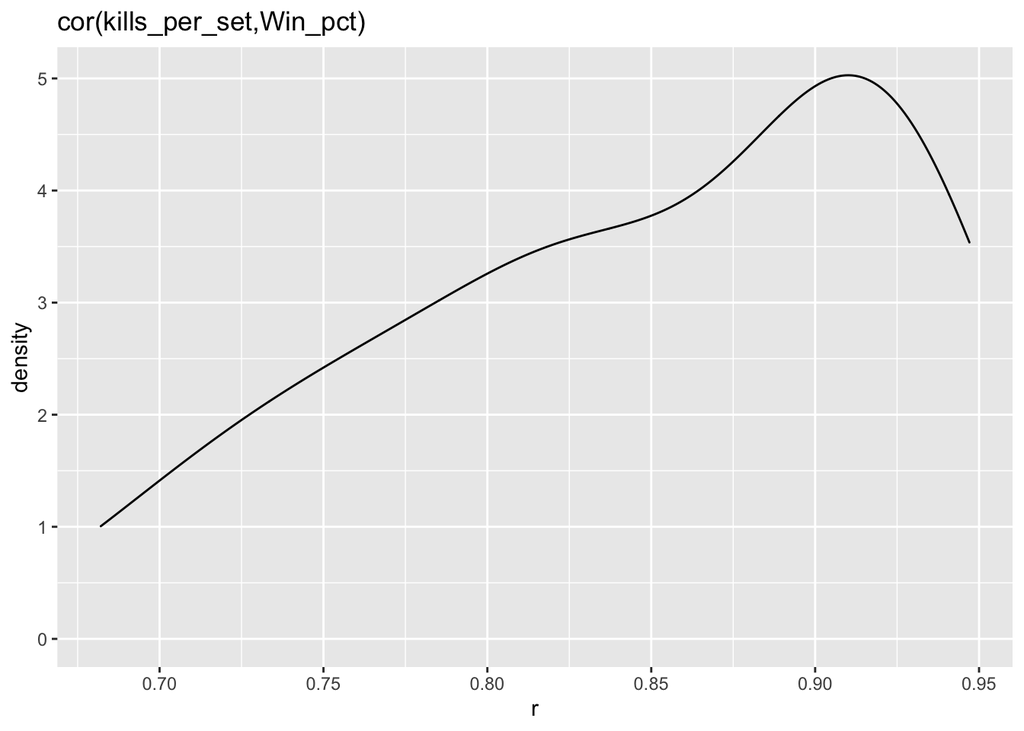

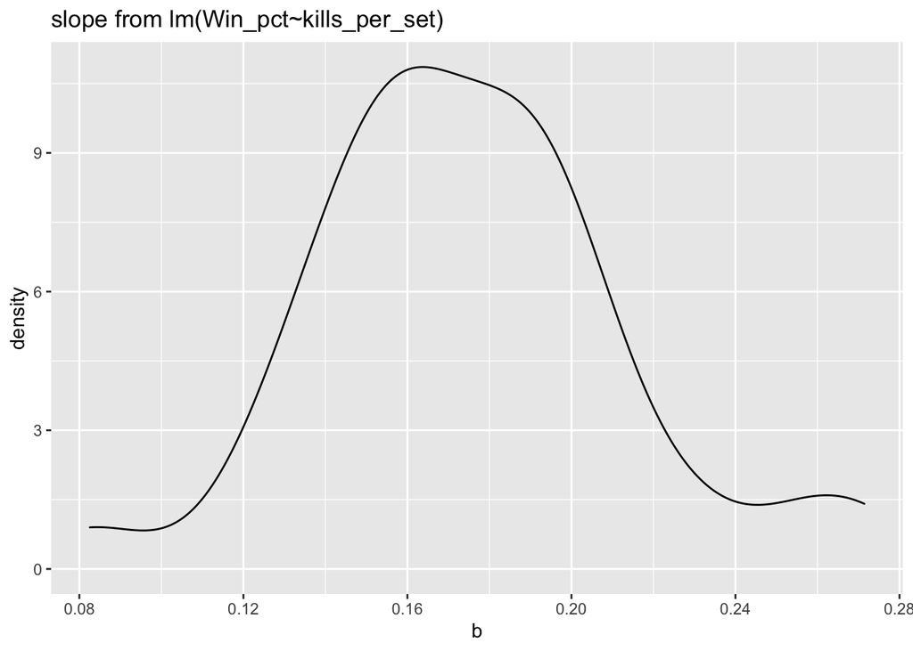

```r
## This function uses some rlang dark magic
##   so that the variable names can be passed in without quotes
##   like in tidyverse functions
## The arguments that are variables in df without quotes need to be
##   wrapped by enquo() so that R does not try to evaluate them
## Then, when we use them we need to "un enquo()" them
##   which is what !! does.
library(rlang)
vb_regression_summary <- function(df,x,y)
{
  x <- enquo(x)
  y <- enquo(y)

  vb_sum <- df %>%
    group_by(Conference) %>%
    summarize(r = cor(!!x,!!y),
              b = get_slope(!!x,!!y))
  g1 <- ggplot(vb_sum, aes(x = r)) +
    geom_density() +
    ggtitle(paste0("cor(",as_name(x),",",as_name(y),")"))
  g2 <- ggplot(vb_sum, aes(x = b)) +
    geom_density() +
    ggtitle(paste0("slope from lm(",as_name(y),"~",as_name(x),")"))
  plot(g1)
  plot(g2)

  return ( invisible(vb_sum) )
}

vb_regression_summary(vb,kills_per_set,Win_pct)
```

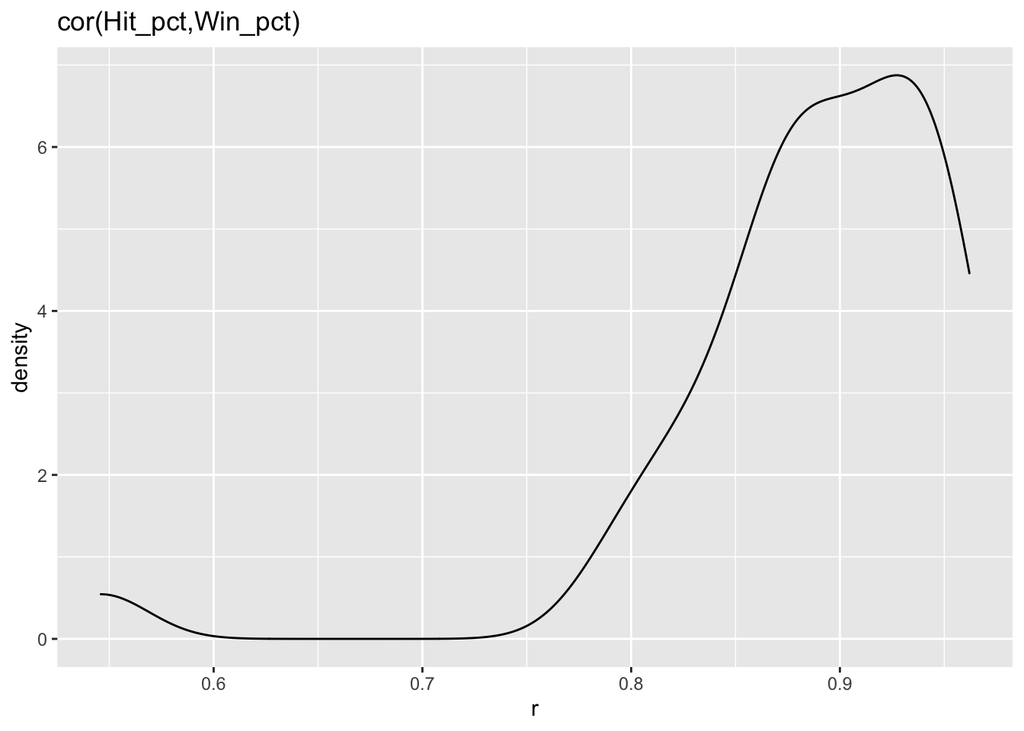

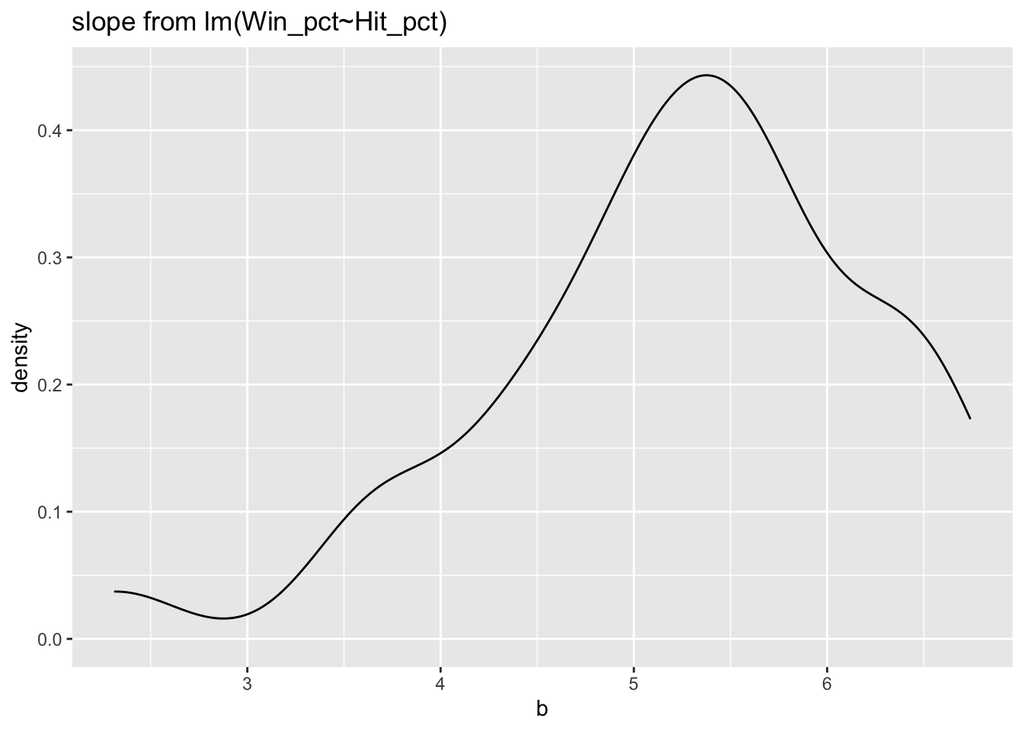

```r
vb_regression_summary(vb,Hit_pct,Win_pct) ## Hit_pct = (Kills - Errors)/`Total Attacks`
```